# CO2 Emissions in Modern Vehicles

Hari Prasannaa Thangavel Ravi, Jin Hyuk Son, Pranjal S. Wakpaijan

2024-12-09

```r
#Load necessary libraries
library(devtools)
library(dplyr)
library(ezids)
library(caret)
library(leaps)
library(car)
library(tidyverse)
```

### **Introduction**

Transportation accounts for a significant share of global greenhouse gas emissions, with vehicles contributing to a substantial share of carbon dioxide (CO2) emissions throughout the world. According to the U.S. Environmental Protection Agency (EPA), the vehicle fuel economy has reached a record high, and the greenhouse gas emissions dropped to record low in 2023. Advancement in automotive technology and stricter regulations led to stronger motivations for improvement in fuel efficiency and reduction in emissions, resulting in average miles per gallon (MPG) increase from 13.1 to 27.1 since 1975 (EPA, 2021).

This project explores the relationship between vehicle characteristics and CO₂ emissions using fuel economy data from the U.S. Department of Energy. The dataset includes vehicle testing results conducted by the EPA or vehicle manufacturers under EPA oversight (U.S. Department of Energy, 2024). For this study, we focus exclusively on vehicles from 2020 to 2024, analyzing attributes such as engine displacement, drivetrain type, and fuel type, with tailpipe CO₂ emissions (in grams per mile) serving as the dependent variable. Electric vehicles (EVs) are excluded due to their fundamentally different emissions profile.

```r
#load the dataset
df <- read.csv("C:\\Users\\HP\\OneDrive\\Documents\\DATS6101-Team4-Project2\\Fuel Economy Data.csv")
```

```r
summary(df)
```

```
##    barrels08      barrelsA08      charge120     charge240         city08
##  Min.   : 0.0   Min.   : 0.00   Min.   :0.0   Min.   : 0.00   Min.   :  6.0
##  1st Qu.:12.4   1st Qu.: 0.00   1st Qu.:0.0   1st Qu.: 0.00   1st Qu.: 15.0
##  Median :14.9   Median : 0.00   Median :0.0   Median : 0.00   Median : 18.0
##  Mean   :15.1   Mean   : 0.19   Mean   :0.0   Mean   : 0.22   Mean   : 19.9
##  3rd Qu.:17.5   3rd Qu.: 0.00   3rd Qu.:0.0   3rd Qu.: 0.00   3rd Qu.: 21.0
##  Max.   :42.5   Max.   :16.53   Max.   :3.2   Max.   :19.00   Max.   :153.0
##
##     city08U         cityA08         cityA08U         cityCD         cityE
##  Min.   :  0.0   Min.   :  0.0   Min.   :  0.0   Min.   :0.00   Min.   :  0.0
##  1st Qu.:  0.0   1st Qu.:  0.0   1st Qu.:  0.0   1st Qu.:0.00   1st Qu.:  0.0
##  Median :  0.0   Median :  0.0   Median :  0.0   Median :0.00   Median :  0.0
##  Mean   :  9.4   Mean   :  0.9   Mean   :  0.8   Mean   :0.00   Mean   :  1.1
##  3rd Qu.: 17.9   3rd Qu.:  0.0   3rd Qu.:  0.0   3rd Qu.:0.00   3rd Qu.:  0.0
##  Max.   :155.8   Max.   :145.0   Max.   :145.1   Max.   :5.35   Max.   :122.0
##
##      cityUF           co2           co2A     co2TailpipeAGpm co2TailpipeGpm
##  Min.   :0.000   Min.   : -1   Min.   : -1   Min.   :  0     Min.   :   0
##  1st Qu.:0.000   1st Qu.: -1   1st Qu.: -1   1st Qu.:  0     1st Qu.: 370
##  Median :0.000   Median : -1   Median : -1   Median :  0     Median : 444
##  Mean   :0.004   Mean   :128   Mean   :  6   Mean   : 16     Mean   : 451
##  3rd Qu.:0.000   3rd Qu.:324   3rd Qu.: -1   3rd Qu.:  0     3rd Qu.: 523
##  Max.   :0.927   Max.   :979   Max.   :713   Max.   :713     Max.   :1270
##
##      comb08         comb08U         combA08       combA08U         combE
##  Min.   :  7.0   Min.   :  0.0   Min.   :  0   Min.   :  0.0   Min.   :  0.0
##  1st Qu.: 17.0   1st Qu.:  0.0   1st Qu.:  0   1st Qu.:  0.0   1st Qu.:  0.0
##  Median : 20.0   Median :  0.0   Median :  0   Median :  0.0   Median :  0.0
##  Mean   : 22.1   Mean   : 10.2   Mean   :  1   Mean   :  0.8   Mean   :  1.2
##  3rd Qu.: 24.0   3rd Qu.: 20.4   3rd Qu.:  0   3rd Qu.:  0.0   3rd Qu.:  0.0
##  Max.   :146.0   Max.   :145.7   Max.   :133   Max.   :133.3   Max.   :121.0
##
##    combinedCD    combinedUF      cylinders       displ        drive
##  Min.   :0.0   Min.   :0.000   Min.   : 2    Min.   :0     Length:48231
##  1st Qu.:0.0   1st Qu.:0.000   1st Qu.: 4    1st Qu.:2     Class :character
##  Median :0.0   Median :0.000   Median : 6    Median :3     Mode  :character
##  Mean   :0.0   Mean   :0.004   Mean   : 6    Mean   :3
##  3rd Qu.:0.0   3rd Qu.:0.000   3rd Qu.: 6    3rd Qu.:4
##  Max.   :4.8   Max.   :0.920   Max.   :16    Max.   :8
##                                NA's   :965   NA's   :963
```

[output cut: 105 more lines]

```
##  Length:48231       Length:48231       Min.   :  0.0   Min.   : 0.0
##  Class :character   Class :character   1st Qu.:  0.0   1st Qu.: 0.0
##  Mode  :character   Mode  :character   Median :  0.0   Median : 0.0
##                                        Mean   :  0.3   Mean   : 0.3
##                                        3rd Qu.:  0.0   3rd Qu.: 0.0
##                                        Max.   :111.0   Max.   :91.0
##
##     phevComb
##  Min.   :  0.0
##  1st Qu.:  0.0
##  Median :  0.0
##  Mean   :  0.3
##  3rd Qu.:  0.0
##  Max.   :101.0
##
```

```r
#defining the unwanted columns (columns realted to fuel type 2 and ev)
unwantedlist <- c(
  "barrelsA08",
  "cityA08",
  "cityA08U",
  "co2A",
  "co2TailpipeAGpm",
  "combA08",
  "combA08U",
  "fuelCostA08",
  "fuelType2",
  "highwayA08",
  "highwayA08U",
  "rangeA",
  "rangeCityA",
  "rangeHwyA",
  "UCityA",
  "UHighwayA",
  "charge120",
  "charge240",
  "sCharger",
  "tCharger",
  "c240Dscr",
  "charge240b",
  "c240bDscr",
  "phevHwy",
  "phevCity",
  "phevComb",
  "modifiedOn",
  "cityCD",
  "combinedCD",
  "highwayCD",
  "phevBlended",
  "cityE",
  "combE",
  "combinedUF",
  "evMotor",
  "highwayE",
  "highwayUF",
  "cityUF",
  "rangeCity",
  "rangeHwy",
  "range",
  "hlv",
  "hpv",
  "pv2",
  "pv4",
  "lv2",
  "lv4",
  "comb08U",
  "city08U",
  "highway08U",
  "engId"
)
cleaned_df <- df %>% select(-all_of(unwantedlist))

#considering only from year 2013
cleaned_df <- cleaned_df %>%
  filter(year %in% (2020:2024))

#removing ev vehicles
cleaned_df <- cleaned_df[!is.na(cleaned_df$cylinders) & cleaned_df$cylinders != "Electricity",]
```

```r
#check the number of missing values for each column
missing_values <- colSums(is.na(cleaned_df))
missing_values
```

```
##      barrels08         city08            co2 co2TailpipeGpm         comb08
##              0              0              0              0              0
##      cylinders          displ          drive       eng_dscr        feScore
##              0              0              0              0              0
##     fuelCost08       fuelType      fuelType1       ghgScore      ghgScoreA
##              0              0              0              0              0
##      highway08             id           make          model        mpgData
##              0              0              0              0              0
##          trany          UCity       UHighway         VClass           year
##              0              0              0              0              0
##   youSaveSpend      baseModel        guzzler     trans_dscr        atvType
##              0              0              0              0              0
##        mfrCode      createdOn      startStop
##              0              0              0
```

```r
#check the number of value 0 for each column
zero_count_per_column <- cleaned_df %>%
  summarise(across(everything(), ~sum(. == 0, na.rm = TRUE)))

zero_count_per_column
```

```
##   barrels08 city08 co2 co2TailpipeGpm comb08 cylinders displ drive eng_dscr
## 1         0      0   0              0      0         0     0     0        0
##   feScore fuelCost08 fuelType fuelType1 ghgScore ghgScoreA highway08 id make
## 1       0          0        0         0        0         0         0  0    0
##   model mpgData trany UCity UHighway VClass year youSaveSpend baseModel guzzler
## 1     0       0     0     0        0      0    0          108         0       0
##   trans_dscr atvType mfrCode createdOn startStop
## 1          0       0       0         0         0
```

```r
#remove columns that are for car identification
cleaned_df <- cleaned_df %>%select(-c(createdOn,mfrCode,baseModel,model,make,id,mpgData,year))
#remove redundant columns and ghg score and fescore, which would be another dependent variable
cleaned_df <- cleaned_df %>%select(-c(co2TailpipeGpm, fuelType, feScore, ghgScore, ghgScoreA,fuelType1))
#remove empty column
cleaned_df <- cleaned_df %>%select(-trans_dscr,atvType)
```

```r
#Identify categorical columns and their unique value counts
categorical_columns <- sapply(cleaned_df, function(col) is.character(col) || is.factor(col))
unique_values <- sapply(cleaned_df[, categorical_columns], function(col) length(unique(col)))

#Separate columns for one-hot and label encoding
one_hot_columns <- names(unique_values[unique_values <= 10]) # Threshold for one-hot encoding
label_columns <- names(unique_values[unique_values > 10])

#Applying One-Hot Encoding
if (length(one_hot_columns) > 0) {
  print(one_hot_columns)
  one_hot_encoded <- dummyVars(~ ., data = cleaned_df[one_hot_columns], fullRank = TRUE)
  one_hot_df <- data.frame(predict(one_hot_encoded, newdata = cleaned_df))
}
```

```
## [1] "drive"     "guzzler"   "atvType"   "startStop"
```

```r
#Applying Label Encoding
for (column in label_columns) {
  cleaned_df[[column]] <- as.numeric(as.factor(cleaned_df[[column]]))
}

#Combining one-hot encoded and remaining data
final_data <- bind_cols(cleaned_df %>% select(-one_hot_columns), one_hot_df)

#View the first few rows of the encoded dataset
print(head(final_data))
```

```
##   barrels08 city08 co2 comb08 cylinders displ eng_dscr fuelCost08 highway08
## 1      8.75     31 257     34         4   2.0       20       1350        40
## 2      5.72     53 170     52         4   1.8       12        900        52
## 3      9.30     29 277     32         4   2.0       20       1450        36
## 4      8.75     31 265     34         4   2.0       20       1350        38
## 5      9.02     30 267     33         4   1.8        1       1400        38
## 6      9.02     29 266     33         4   1.8        1       1400        39
##   trany UCity UHighway VClass youSaveSpend driveAll.Wheel.Drive
## 1    11  41.0     58.7      1         1500                    0
## 2    21  78.1     76.2      1         3750                    0
## 3    29  37.9     53.4      1         1000                    0
## 4    11  40.5     56.8      1         1500                    0
## 5    21  39.3     56.2      1         1250                    0
## 6    29  38.6     58.4      1         1250                    0
##   driveFront.Wheel.Drive drivePart.time.4.Wheel.Drive driveRear.Wheel.Drive
```

[output cut: 20 more lines]

```r
#removing categorical variables with two many categories - avoid overfitting
linear_df <- final_data %>%select(-c(trany, eng_dscr, VClass))
#remove any mpg because co2 is directly related to mpg (which is tailpipe CO2 in grams/mile)
#also remove barrels08 as it is basically proportional to co2
#linear_df <- linear_df %>%select(-c(comb08, UCity, UHighway, highway08, city08, barrels08))
linear_df <- linear_df %>%select(-c(comb08,UCity,UHighway,highway08, city08, barrels08))
```

```r
library(leaps)
regfit_full <- regsubsets(co2 ~ ., data = linear_df, nvmax = 35)
reg_summary <- summary(regfit_full)
```

```r
# Find the model size using adjusted r squared
best_model_size <- which.max(reg_summary$adjr2)
best_model_size
```

```
## [1] 14
```

```r
#Column names of the best model size
selected_vars <- names(which(reg_summary$which[best_model_size, ])) %>%
  setdiff("(Intercept)")  # Remove intercept

#filter for the column names above
selected_data <- final_data %>%
  select(all_of(selected_vars)) %>%
  mutate(co2 = final_data$co2) #add our dependent variable
```

```r
#We are going to run VIF to check multicollinearity

vif_model <- lm(co2 ~ ., data = selected_data)

vif_values <- vif(vif_model)

vif_df <- as.data.frame(vif_values) %>%
  rownames_to_column(var = "Variable")
print(vif_df)
```

```
##                        Variable vif_values
## 1                     cylinders       9.10
## 2                         displ       7.92
## 3                    fuelCost08     307.47
## 4                  youSaveSpend     320.12
## 5          driveAll.Wheel.Drive       2.65
## 6        driveFront.Wheel.Drive       2.87
## 7  drivePart.time.4.Wheel.Drive       1.32
## 8         driveRear.Wheel.Drive       2.18
## 9                      guzzlerG       1.53
## 10                atvTypeDiesel       1.10
## 11                   atvTypeFFV       1.05
## 12                atvTypeHybrid       1.19
## 13        atvTypePlug.in.Hybrid       5.37
## 14                   startStopY       1.28
```

```r
#remove the highest VIF
lm_data <- selected_data %>%
  select(-youSaveSpend)
#lm_data <- lm_data %>%select(-cylinders)
lm_data <- lm_data %>%
  select(-fuelCost08)

#run vif again
vif_model <- lm(co2 ~ ., data = lm_data)
vif_values <- vif(vif_model)
vif_df <- as.data.frame(vif_values) %>%
  rownames_to_column(var = "Variable")
print(vif_df)
```

```
##                        Variable vif_values
## 1                     cylinders       7.99
## 2                         displ       7.89
## 3          driveAll.Wheel.Drive       2.64
## 4        driveFront.Wheel.Drive       2.53
## 5  drivePart.time.4.Wheel.Drive       1.30
## 6         driveRear.Wheel.Drive       2.17
## 7                      guzzlerG       1.47
## 8                 atvTypeDiesel       1.08
## 9                    atvTypeFFV       1.04
## 10                atvTypeHybrid       1.11
## 11        atvTypePlug.in.Hybrid       1.05
## 12                   startStopY       1.26
```

### **Research Question 1**

How do key vehicle attributes, including engine size, drivetrain type, and hybrid status, impact CO₂ emissions in vehicles from 2020 to 2024, and how accurately can the model predict CO₂ emissions compared to actual observed values?

#### **Method**

we employed a linear regression model to quantify the relationships between CO₂ emissions (the dependent variable) and key vehicle features.The model was trained on data from 2020 to 2024 and validated on a separate test set to evaluate its predictive performance.

```r
lm_model <- lm(co2 ~ ., data = lm_data)
summary(lm_model)
```

```
##
## Call:
## lm(formula = co2 ~ ., data = lm_data)
##
## Residuals:
##     Min      1Q  Median      3Q     Max
## -180.92  -30.93   -2.32   27.79  298.55
##
## Coefficients:
##                              Estimate Std. Error t value Pr(>|t|)
## (Intercept)                   252.667      3.292   76.75  < 2e-16 ***
## cylinders                      21.871      0.904   24.19  < 2e-16 ***
## displ                          22.704      1.283   17.69  < 2e-16 ***
## driveAll.Wheel.Drive          -26.602      2.037  -13.06  < 2e-16 ***
## driveFront.Wheel.Drive        -81.291      2.361  -34.43  < 2e-16 ***
## drivePart.time.4.Wheel.Drive   15.657      3.246    4.82  1.4e-06 ***
## driveRear.Wheel.Drive         -33.940      2.068  -16.42  < 2e-16 ***
## guzzlerG                       39.975      3.122   12.80  < 2e-16 ***
## atvTypeDiesel                  -5.040      4.397   -1.15     0.25
## atvTypeFFV                     -2.624      5.279   -0.50     0.62
## atvTypeHybrid                 -66.198      1.906  -34.73  < 2e-16 ***
## atvTypePlug.in.Hybrid        -212.311      3.349  -63.40  < 2e-16 ***
## startStopY                      8.904      1.435    6.21  5.8e-10 ***
## ---
## Signif. codes:  0 '***' 0.001 '**' 0.01 '*' 0.05 '.' 0.1 ' ' 1
##
## Residual standard error: 46 on 5847 degrees of freedom
## Multiple R-squared:  0.827,  Adjusted R-squared:  0.826
## F-statistic: 2.33e+03 on 12 and 5847 DF,  p-value: <2e-16
```

Model Validation: We split the data into training and test sets using an 80/20 split. A linear model was fitted using the lm() function in R, including all relevant predictors. Model evaluation was done using metrics such as RMSE (Root Mean Squared Error) and R-squared. The results indicated a Test RMSE of 47.95 and a Test R-squared of 0.81, suggesting a strong model fit with good predictive power.

```r
set.seed(123)
train_index <- sample(seq_len(nrow(lm_data)), size = 0.8 * nrow(lm_data))
train_data <- lm_data[train_index, ]
test_data <- lm_data[-train_index, ]

lm_train_model <- lm(co2 ~ ., data = train_data)

test_predictions <- predict(lm_train_model, newdata = test_data)
test_residuals <- test_data$co2 - test_predictions


rmse <- sqrt(mean(test_residuals^2))
r_squared <- 1 - (sum(test_residuals^2) / sum((test_data$co2 - mean(test_data$co2))^2))

print(paste("Test RMSE:", round(rmse, 2)))
```

```
## [1] "Test RMSE: 47.95"
```

```r
print(paste("Test R-squared:", round(r_squared, 2)))
```

```
## [1] "Test R-squared: 0.81"
```

#### **Analysis**

The linear regression model provided insights into how different vehicle attributes affect CO₂ emissions: The model explains 81% of the variability in CO₂ emissions on the test dataset. This is a strong indication that the model captures most of the patterns and relationships within the data. The remaining 19% of the variance is unexplained by the model, suggesting that there may be other factors influencing CO₂ emissions not captured by the current set of predictors. The graph illustrates the performance of a model predicting CO2 emissions. The model generally predicts CO2 emissions well as the data points are clustered around the red dashed line. However, there are several data points that are far from the ideal line, indicating that the model underestimates or overestimates CO2 emissions in some cases.

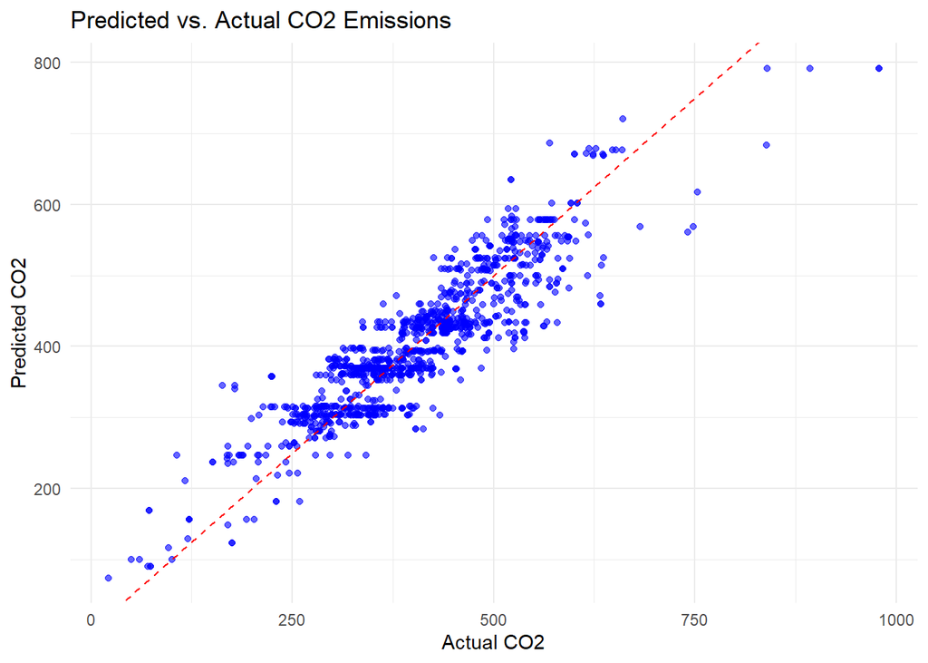

```r
ggplot(data.frame(Actual = test_data$co2, Predicted = test_predictions), aes(x = Actual, y = Predicted)) +
  geom_point(alpha = 0.6, color = "blue") +
  geom_abline(slope = 1, intercept = 0, linetype = "dashed", color = "red") +
  labs(title = "Predicted vs. Actual CO2 Emissions", x = "Actual CO2", y = "Predicted CO2") +
  theme_minimal()
```

### **Research Question 2**

How can clustering vehicle attributes reveal distinct groups of vehicles, and which group exhibits the lowest CO2 emissions, making them the most sustainable, among models from 2020 to 2024?

#### **Method**

In this analysis, we have clustered vehicles based on important features identified in earlier finding. To do so, we have used K-means clustering method. K-means clustering is an unsupervised machine learning method that assigns data points to one of the clusters based on their distance from the center of each cluster. The algorithm initially assigns centroid randomly. It then recalculates the centroids based on the mean of the assigned data points and iterate this process until the centroids no longer change significantly.

To choose the number of clusters, we have applied the Elbow Method. The method is described as follows: - *Calculate the Within-Cluster-Sum of Squared Errors (WSS) for different values of k, and choose the k for which WSS becomes first starts to diminish. In the plot of WSS-versus-k, this is visible as an elbow.* (Mahendru, 2019)

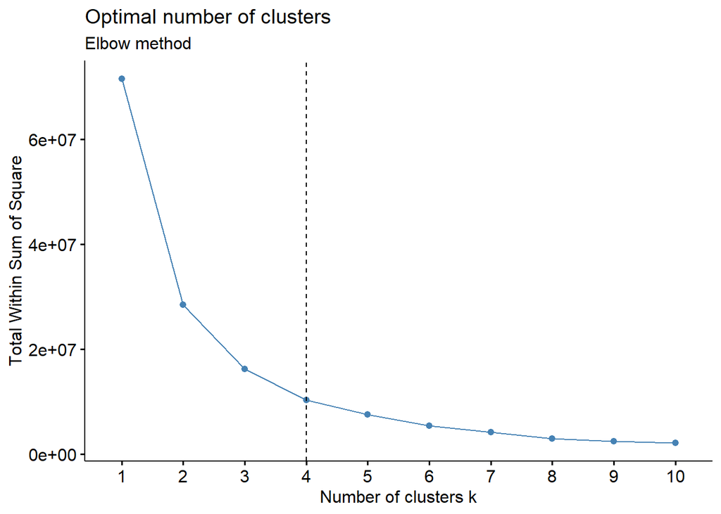

```r
library(factoextra)
cluster_df <- lm_data

# Elbow method
fviz_nbclust(cluster_df, kmeans, method = "wss") +
    geom_vline(xintercept = 4, linetype = 2)+
  labs(subtitle = "Elbow method")
```

The point at which the WSS curve began to flatten suggested that 4 clusters would be the most appropriate number, as adding more clusters beyond this point would not yield a significant improvement.

#### **Analysis**

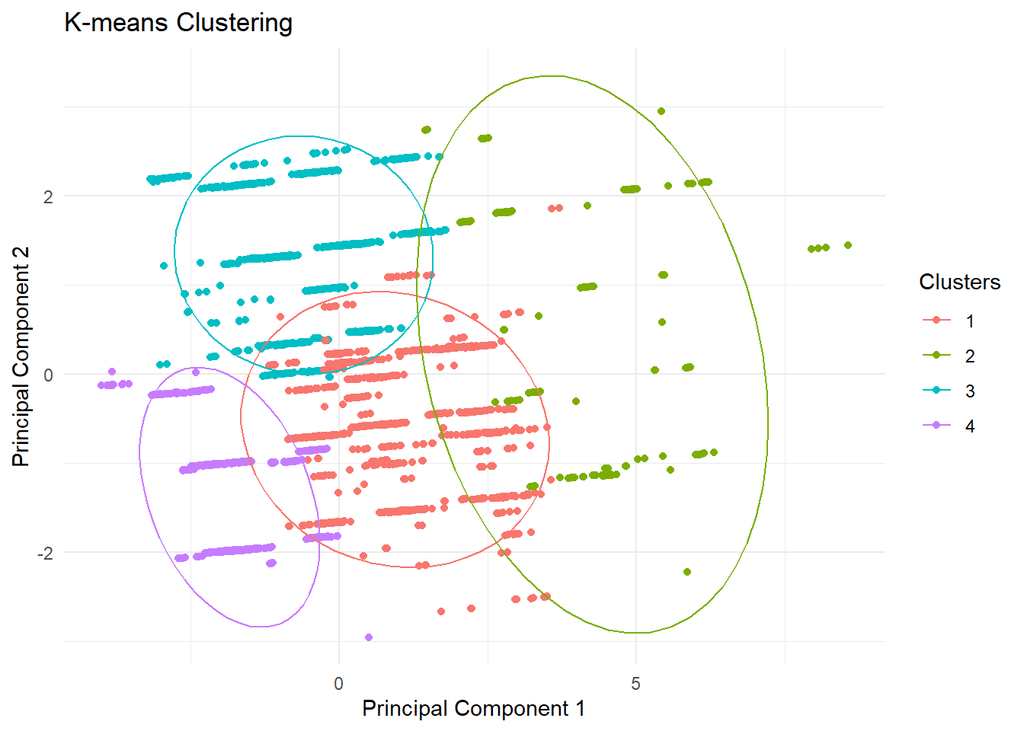

```r
# Compute k-means with k = 4
set.seed(123)
#scaling
scaled_df <- scale(cluster_df)
km_res <- kmeans(scaled_df, 4, nstart = 25)
# Add cluster assignments to the original data for visualization
cluster_df$Cluster <- as.factor(km_res$cluster)

# PCA for dimensionality reduction
pca_result <- prcomp(scaled_df)
pca_df <- data.frame(pca_result$x)

# Plotting with ggplot2
ggplot(pca_df, aes(x = PC1, y = PC2, color = cluster_df$Cluster)) +
  geom_point() +
  stat_ellipse(level = 0.95) +  # Add ellipses around clusters (95% confidence intervals)
  labs(title = "K-means Clustering",
       x = "Principal Component 1", y = "Principal Component 2", color = "Clusters") +
  theme_minimal()
```

To better understand the characteristics that define each cluster, we examined the distribution of engine displacement across the four groups. The boxplot revealed that Cluster 2 consistently exhibited higher engine displacement compared to the other clusters. To statistically validate this observation, we conducted an ANOVA test, which returned a low p-value, indicating a significant difference in engine displacement between the clusters.

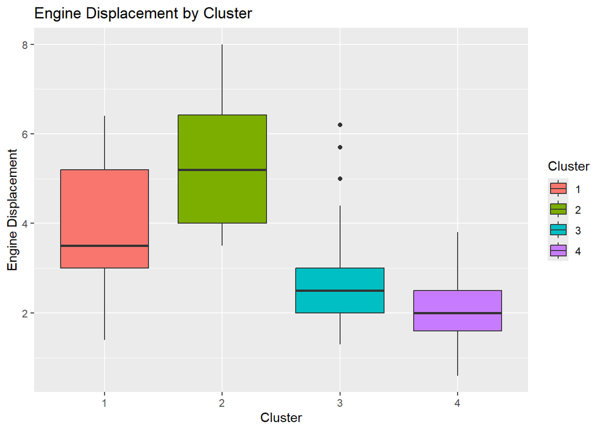

```r
# Create boxplots for engine displacement
ggplot(cluster_df, aes(x = Cluster, y = displ, fill = Cluster)) +
  geom_boxplot() +
  labs(title = "Engine Displacement by Cluster", x = "Cluster", y = "Engine Displacement")
```

```r
# ANOVA for 'displ' across clusters
anova_displ <- aov(displ ~ Cluster, data = cluster_df)
summary(anova_displ)
```

```
##               Df Sum Sq Mean Sq F value Pr(>F)
## Cluster        3   4186    1395    1372 <2e-16 ***
## Residuals   5856   5958       1
## ---
## Signif. codes:  0 '***' 0.001 '**' 0.01 '*' 0.05 '.' 0.1 ' ' 1
```

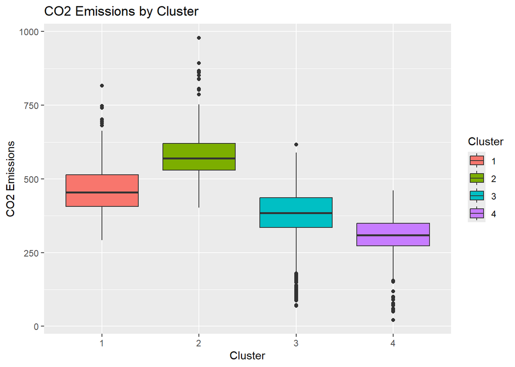

```r
# Create boxplots for co2 by cluster
ggplot(cluster_df, aes(x = Cluster, y = co2, fill = Cluster)) +
  geom_boxplot() +
  labs(title = "CO2 Emissions by Cluster", x = "Cluster", y = "CO2 Emissions")
```

```r
# ANOVA for 'displ' across clusters
anova_co2 <- aov(displ ~ co2, data = cluster_df)
summary(anova_co2)
```

```
##               Df Sum Sq Mean Sq F value Pr(>F)
## co2            1   6236    6236    9348 <2e-16 ***
## Residuals   5858   3908       1
## ---
## Signif. codes:  0 '***' 0.001 '**' 0.01 '*' 0.05 '.' 0.1 ' ' 1
```

Based on the mean values for each feature across the 4 clusters, we can describe the defining characteristics of each group as follows:

```r
# Calculate the mean of each numeric column grouped by cluster
cluster_means <- cluster_df %>%
  group_by(Cluster) %>%
  summarise(across(where(is.numeric), mean, na.rm = TRUE))


# View the mean of all columns by cluster
xkabledplyhead(cluster_means, 4)
```

Head

| Cluster | cylinders | displ | driveAll.Wheel.Drive | driveFront.Wheel.Drive | drivePart.time.4.Wheel.Drive | driveRear.Wheel.Drive | guzzlerG | atvTypeDiesel | atvTypeFFV | atvTypeHybrid | atvTypePlug.in.Hybrid | startStopY | co2 |
| --- | --- | --- | --- | --- | --- | --- | --- | --- | --- | --- | --- | --- | --- |
| 1 | 6.27 | 3.77 | 0.0187 | 0.000 | 0.1219 | 0.5857 | 0.000 | 0.0581 | 0.0346 | 0.0586 | 0.0014 | 0.612 | 460 |
| 2 | 9.48 | 5.35 | 0.4559 | 0.000 | 0.0029 | 0.5353 | 0.997 | 0.0000 | 0.0029 | 0.0294 | 0.0059 | 0.488 | 592 |
| 3 | 5.15 | 2.70 | 0.8862 | 0.000 | 0.0093 | 0.0056 | 0.000 | 0.0000 | 0.0000 | 0.2202 | 0.0780 | 0.859 | 379 |
| 4 | 4.18 | 2.15 | 0.0000 | 0.944 | 0.0000 | 0.0031 | 0.000 | 0.0000 | 0.0055 | 0.1067 | 0.0249 | 0.503 | 305 |

- Cluster 1
  - Moderate to high numbers for cylinder (6.27) and engine displacement (3.77).
  - Majority of the vehicles are rear-wheel drive.
- Cluster 2
  - High numbers for cylinder (9.48) and engine displacement (5.35).
  - Either all-wheel drive or rear-wheel drive vehicles.
  - Mostly gas guzzlers, indicating very low fuel efficiency. Likely to be larger vehicles such as trucks.
- Cluster 3
  - Moderate number for cylinders (5.15) and low number for engine displacement (2.70).
  - Mostly all-wheel drive vehicles and characterized by start-stop systems.
- Cluster 4
  - Low numbers for cylinders (4.18) and engine displacement (2.15).
  - Mostly front-wheel drive vehicles, likely to be compact cars.

By examining these clusters, we can draw several conclusions about sustainability and emissions. Cluster 2, with its larger engines and higher emissions, represents the least sustainable group, while Clusters 3 and 4, with their smaller engines and lower emissions, reflect more fuel-efficient, environmentally friendly vehicles. Cluster 1 falls somewhere in between, with moderate emissions and a mix of vehicle types. This analysis helps identify which vehicle features contribute most to CO₂ emissions and which types of vehicles are more sustainable.

### **References**

EPA Press Office. (2024, November 25). EPA Report Shows US Fuel Economy Hits Record High and CO2 Emissions Reach a Record Low. EPA. https://www.epa.gov/newsreleases/epa-report-shows-us-fuel-economy-hits-record-high-and-co2-emissions-reach-record-low#:~:text=For%20MY%202023%2C%20new%20vehicle,of%20319%20grams%20per%20mile.

Mahendru, K. (2019, June 17). *How to determine the optimal K for K-means?*. Medium. https://medium.com/analytics-vidhya/how-to-determine-the-optimal-k-for-k-means-708505d204eb

U.S. Department of Energy. (n.d.). *Fueleconomy.gov web services*. www.fueleconomy.gov. https://www.fueleconomy.gov/feg/ws/index.shtml#vehicle